# Midpoint Deliverable

## Introduction

For this project, we are looking at the domain of education with a focus on the financial characteristics of schools over the past twenty years and how they has differ over time and geographic location.

To look into this, we are using compiled datasets from the U.S. Census Bureau as authorized by Title 13, United States Code, Section 161 and 182. Under this authorization, we are able to access surveys of every school in the United States, including Washington D.C., in order to collect information on education finance data such as revenue, expenditure, debt, and assets of elementary and secondary public school systems.

We have used this information to provide a general overview and learn about aspects of it including education funding for the country over time, how much surplus or over-use states had in a specific year, yearly debt/surplus, and the breakdown in funding by source.

## Table of Aggregated Data

This table is grouped by year and shows the raw values for variables such as number of students, Total Revenue (and its breakdown from Federal, State, and Local sources), and Total Expenditures (Salaries and Teacher Saleries) for each year.

| Year | Students | Total Revenue | Federal Revenue | State Revenue | Local Revenue | Total Expenditures | Salaries | Teacher Revenue |
| --- | --- | --- | --- | --- | --- | --- | --- | --- |
| 1995 | 43806383 | 321679.5 | 21383.45 | 146702.7 | 153593.4 | 322970.0 | 183526.5 | 124955.2 |
| 1996 | 44576673 | 331172.5 | 21478.47 | 154252.4 | 155441.6 | 336683.8 | 186918.1 | 128518.8 |
| 1997 | 45310145 | 345383.1 | 22752.80 | 160867.8 | 161762.5 | 351195.7 | 192965.3 | 132880.5 |
| 1998 | 45804899 | 363601.5 | 25637.54 | 169654.3 | 168309.6 | 366431.6 | 201551.4 | 138616.9 |
| 1999 | 46157307 | 386184.2 | 28048.86 | 185394.4 | 172740.9 | 389552.3 | 212179.5 | 145418.6 |
| 2000 | 46433245 | 410473.3 | 31593.00 | 199902.6 | 178977.7 | 413939.0 | 225150.4 | 153730.5 |
| 2001 | 46882320 | 438432.5 | 33118.56 | 211794.2 | 193519.7 | 442812.2 | 237436.8 | 161164.2 |
| 2002 | 47323109 | 460547.4 | 37888.73 | 220739.4 | 201919.3 | 469664.7 | 249901.0 | 169023.8 |
| 2003 | 47852623 | 477361.7 | 42052.52 | 227542.5 | 207766.7 | 485740.7 | 257674.7 | 173997.0 |
| 2004 | 48156039 | 501718.4 | 47102.78 | 232577.9 | 222037.8 | 505802.1 | 263131.3 | 178707.7 |
| 2005 | 48414370 | 521533.6 | 48074.52 | 244106.1 | 229353.1 | 522465.3 | 270077.3 | 183051.4 |
| 2006 | 48706127 | 553133.3 | 49623.64 | 258685.7 | 244824.0 | 551706.8 | 281220.0 | 190451.6 |
| 2007 | 48852324 | 590751.0 | 49721.38 | 280751.4 | 260278.2 | 589160.6 | 296601.6 | 200342.8 |
| 2008 | 48938103 | 621222.7 | 50071.05 | 298380.6 | 272771.0 | 627107.3 | 311920.8 | 210551.3 |
| 2009 | 48979100 | 630964.7 | 57593.14 | 300460.1 | 272911.5 | 641108.3 | 323265.0 | 217499.7 |
| 2010 | 49054631 | 645451.1 | 78081.04 | 286555.3 | 280814.7 | 651956.6 | 328884.2 | 221842.6 |
| 2011 | 49111455 | 650050.6 | 77008.90 | 292196.9 | 280844.8 | 652255.6 | 325952.3 | 220775.9 |
| 2012 | 49221199 | 654407.1 | 63689.56 | 300757.6 | 289960.0 | 654090.8 | 327098.4 | 221527.0 |
| 2013 | 49391855 | 655944.0 | 57474.25 | 305698.1 | 292771.7 | 655328.0 | 329065.9 | 222915.2 |
| 2014 | 49580180 | 677196.2 | 55754.24 | 322973.0 | 298469.0 | 676384.5 | 334366.3 | 225517.0 |
| 2015 | 49865160 | 701019.0 | 56638.90 | 337887.8 | 306492.3 | 698928.4 | 340797.0 | 229677.6 |
| 2016 | 50005738 | 715611.7 | 56559.55 | 344524.5 | 314527.6 | 715250.9 | 349618.9 | 234804.9 |

## USA Education Funding Over Time

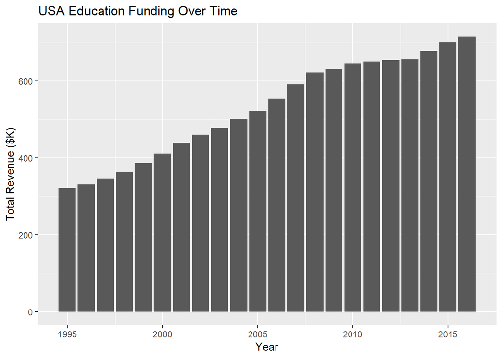

## Education Funding Surplus

This chart shows the surplus in 2000 education funds for mainland U.S. states. We decided to go with a choropleth map because it gives a clear visualization of each state, also allowing us to see trends over the country as a whole based on location. In addition, the color gradient makes it easy to see the range of surplus amount among states from positive to negative very easily at a glance.

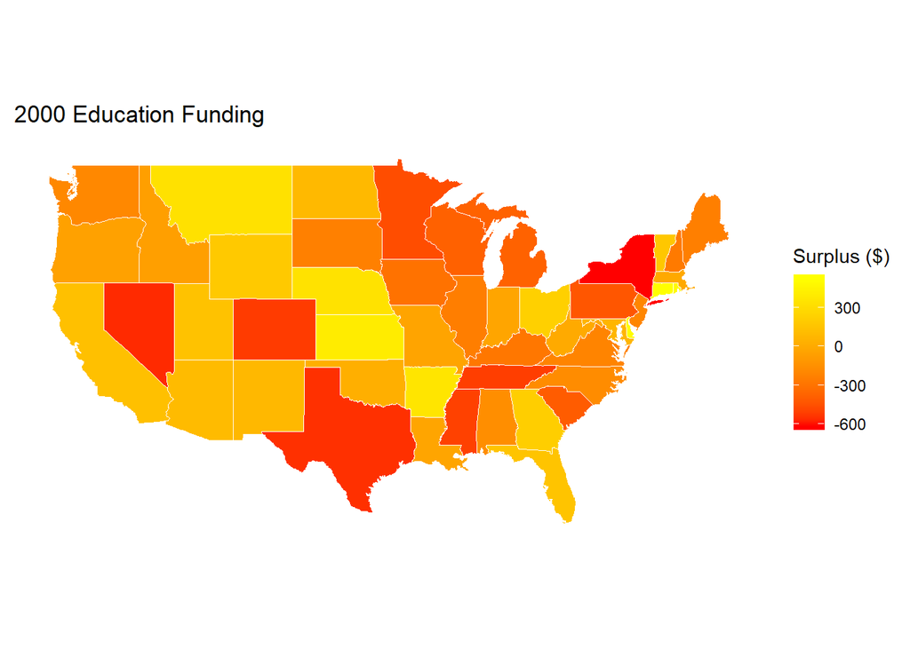

## Education Spending

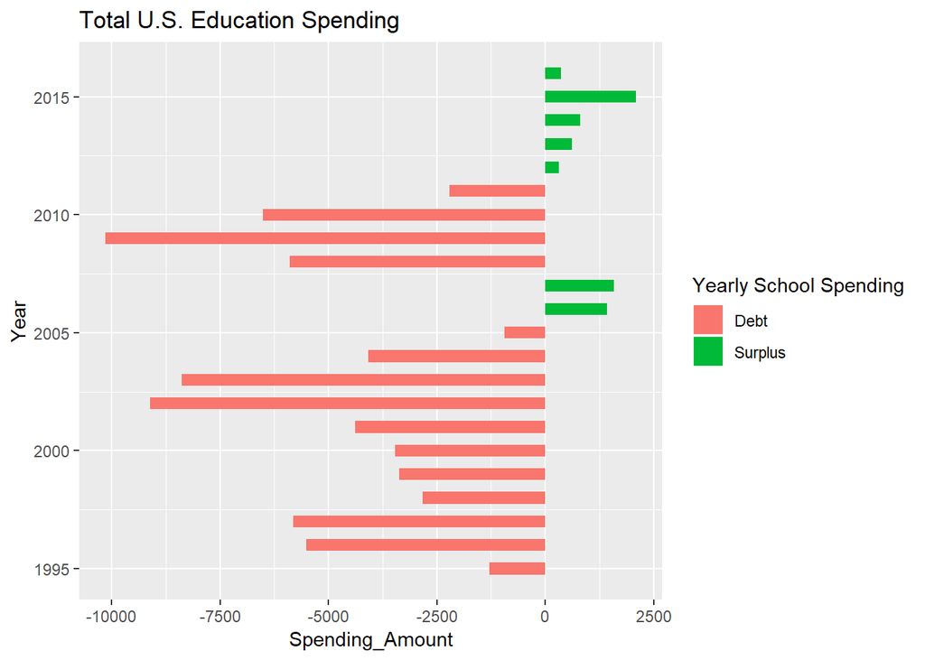

## Funding Over Time, by Source

This chart shows the relationship between Federal, State, and Local funding for the country over the years. We decided to go with a scatter plot for an easy comparison of each source which allows us to quickly see and compare how funding in each changed with each year.

#### Source

Blue - Federal Funding

Red - State Funding

Green - Local Funding

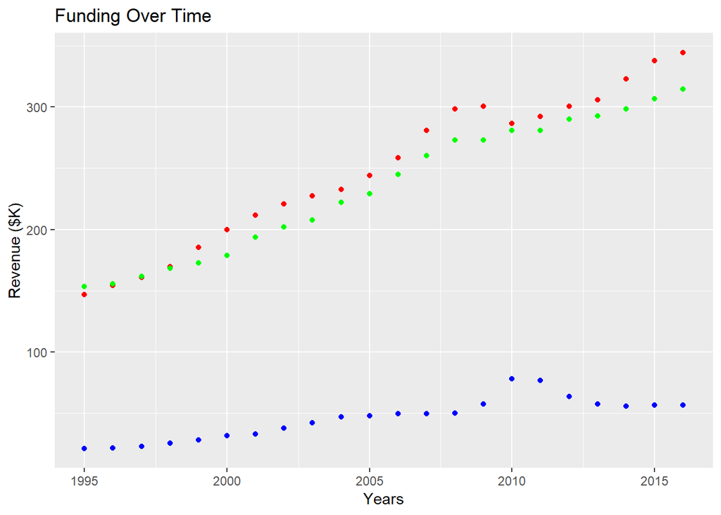